# Graphical Comparison

He Jinlin & Wang Yuan

January 26, 2017

## Todo:

Change level name under “MatchingScheme” Tidy up variables * Data to start with: All entries without time limit.

- Response Variables
  - timeUsedPerShape
  - errorPerShape
- Factors of Interest
  - TimerDisplay
  - MatchingScheme

### Cleaning the data

1. Loading dataset from the website:

```r
library(data.table)
#shape <- read.csv("~/Desktop/MAP/Original.csv", stringsAsFactors = F)
shape <- fread("http://kuiper.pearsoncmg.com/shapesplosion/webreporter.php?game=PerfectionFlash&groupID=&winlose=both&random=false&rows=&type=csv")
```

2. Using data with unlimited playtime yet playtime > 0:

```r
shape_untime <- shape[shape$requestedTime==0,]
shape_untimed <- shape_untime[shape_untime$timeUsed!=0,]
```

3.For all the plots below, TimeUsed is computed in terms of seconds. It is also logged during plotting to highlight the difference in comparison.

```r
shape_untimed$timeUsed = as.numeric(shape_untimed$timeUsed)
shape_untimed$numShapes = as.numeric(shape_untimed$numShapes)

shape_untimed_sec <-mutate(shape_untimed, TimeUsedSec = shape_untimed$timeUsed/1000)
```

4.Creating a new column with time used per shape and error per shape:

```r
shape_untimed_sec <- mutate(shape_untimed_sec, timeUsedPerShape=(TimeUsedSec/numShapes))
shape_untimed_sec <- mutate(shape_untimed_sec,errorPerShape=(as.numeric(numErrors)/as.numeric(numShapes)))
```

## Realizing there is a significant outlier that used more than 4000 seconds (67 minutes), we decided to remove the single outlier.

```r
shape_untimed_truncate = shape_untimed_sec[shape_untimed_sec$TimeUsedSec<=4000,]
```

5. Converting the categorical variables such as numShapes in numerical forms into factors

```r
shape_untimed_sec$numShapes = as.factor(shape_untimed_sec$numShapes)
shape_untimed_sec$timerDisplay = as.factor(shape_untimed_sec$timerDisplay)
shape_untimed_sec$matchingScheme = as.factor(shape_untimed_sec$matchingScheme)
shape_untimed_sec$timerDisplay = as.factor(shape_untimed_sec$timerDisplay)
shape_untimed_sec$numErrors = as.numeric(shape_untimed_sec$numErrors)
```

Now we subset a *Sample B* out of *Sample A* using the most popular Group IDs: **GroupIDs that contain “6002”** GroupIDs of MAT 209 class **The most GroupIDs: “HotchkissStudent16”"

```r
##groupID_count <- count_(shape_untimed_sec,"groupID")
group_6002<-shape_untimed_sec[like(groupID,"6002")]
MAT_209<-shape_untimed_sec[like(tolower(groupID),"mat209")]
shape_HotchkissStudent16<-shape_untimed_sec[shape_untimed_sec$groupID=="HotchkissStudent16",]

##as.data.frame(table($groupID))
##tb <- tb[order(-tb$Freq),]
##tb <- tb[tb$Freq > 25,]
```

## Approach 1: Same Plots With Different Sample Size (*Sample A* and *Sample B*)

### ‘timeUsedPerShape’ as Response Variable

### 1: Log(timeUsedPerShape ~ MatchingScheme)

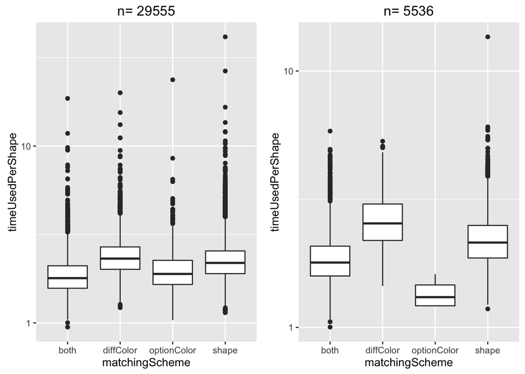

```r
plot1 = ggplot(data = shape_untimed_truncate, aes(x=matchingScheme, y=timeUsedPerShape)) + geom_boxplot()  +  scale_y_log10() + theme(legend.position="top") + labs(title=paste("n=",dim(shape_untimed_truncate)[1]))

plot2 = ggplot(data = group_6002, aes(x=matchingScheme, y=timeUsedPerShape)) + geom_boxplot()  + scale_y_log10() + theme(legend.position="top") + labs(title=paste("n=",dim(group_6002)[1]))
grid.arrange(plot1, plot2, ncol=2)
```

Linear Regression:

```r
mod1 <- lm(timeUsedPerShape ~ matchingScheme, data = shape_untimed_truncate)
mod2 <- lm(timeUsedPerShape ~ matchingScheme, data = group_6002)
summary(mod1)
```

```
##
## Call:
## lm(formula = timeUsedPerShape ~ matchingScheme, data = shape_untimed_truncate)
##
## Residuals:
##    Min     1Q Median     3Q    Max
## -1.215 -0.406 -0.134  0.230 39.147
##
## Coefficients:
##                           Estimate Std. Error t value Pr(>|t|)
## (Intercept)                1.93555    0.01032 187.482  < 2e-16 ***
## matchingSchemediffColor    0.49841    0.01390  35.851  < 2e-16 ***
## matchingSchemeoptionColor  0.12352    0.02276   5.428 5.75e-08 ***
## matchingSchemeshape        0.37787    0.01176  32.132  < 2e-16 ***
## ---
## Signif. codes:  0 '***' 0.001 '**' 0.01 '*' 0.05 '.' 0.1 ' ' 1
##
## Residual standard error: 0.7338 on 29551 degrees of freedom
## Multiple R-squared:  0.04905,    Adjusted R-squared:  0.04896
## F-statistic: 508.1 on 3 and 29551 DF,  p-value: < 2.2e-16
```

```r
summary(mod2)
```

```
##
## Call:
## lm(formula = timeUsedPerShape ~ matchingScheme, data = group_6002)
##
## Residuals:
##     Min      1Q  Median      3Q     Max
## -1.2031 -0.3741 -0.1229  0.2198 11.3404
##
## Coefficients:
##                           Estimate Std. Error t value Pr(>|t|)
## (Intercept)                1.92906    0.01377 140.086   <2e-16 ***
## matchingSchemediffColor    0.72525    0.02999  24.185   <2e-16 ***
## matchingSchemeoptionColor -0.56406    0.29933  -1.884   0.0596 .
## matchingSchemeshape        0.32510    0.01742  18.663   <2e-16 ***
## ---
## Signif. codes:  0 '***' 0.001 '**' 0.01 '*' 0.05 '.' 0.1 ' ' 1
##
## Residual standard error: 0.598 on 5532 degrees of freedom
## Multiple R-squared:  0.113,  Adjusted R-squared:  0.1125
## F-statistic:   235 on 3 and 5532 DF,  p-value: < 2.2e-16
```

### 2. Log(timeUsedPerShape ~ TimerDisplay)

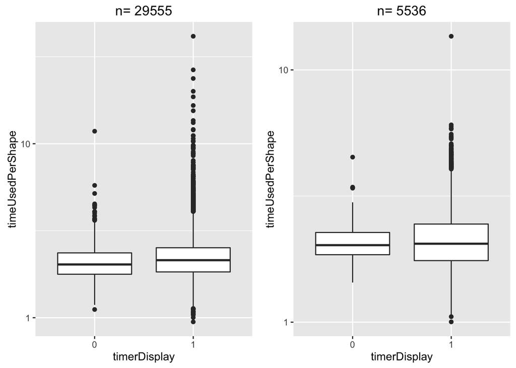

```r
plot3 = ggplot(data = shape_untimed_truncate, aes(x=timerDisplay, y=timeUsedPerShape)) + geom_boxplot()  +  scale_y_log10() + theme(legend.position="top") + labs(title=paste("n=",dim(shape_untimed_truncate)[1]))

plot4 = ggplot(data = group_6002, aes(x=timerDisplay, y=timeUsedPerShape)) + geom_boxplot()  + scale_y_log10() + theme(legend.position="top") + labs(title=paste("n=",dim(group_6002)[1]))
grid.arrange(plot3, plot4, ncol=2)
```

```r
mod3 <- lm(timeUsedPerShape ~ timerDisplay, data = shape_untimed_truncate)
mod4 <- lm(timeUsedPerShape ~ timerDisplay, data = group_6002)
summary(mod3)
```

```
##
## Call:
## lm(formula = timeUsedPerShape ~ timerDisplay, data = shape_untimed_truncate)
##
## Residuals:
##    Min     1Q Median     3Q    Max
## -1.320 -0.431 -0.125  0.256 39.193
##
## Coefficients:
##               Estimate Std. Error t value Pr(>|t|)
## (Intercept)    2.13353    0.02511  84.959  < 2e-16 ***
## timerDisplay1  0.13342    0.02550   5.232 1.69e-07 ***
## ---
## Signif. codes:  0 '***' 0.001 '**' 0.01 '*' 0.05 '.' 0.1 ' ' 1
##
## Residual standard error: 0.7521 on 29553 degrees of freedom
## Multiple R-squared:  0.0009253,  Adjusted R-squared:  0.0008914
## F-statistic: 27.37 on 1 and 29553 DF,  p-value: 1.692e-07
```

```r
summary(mod4)
```

```
##
## Call:
## lm(formula = timeUsedPerShape ~ timerDisplay, data = group_6002)
##
## Residuals:
##     Min      1Q  Median      3Q     Max
## -1.1780 -0.4232 -0.1334  0.2653 11.4138
##
## Coefficients:
##               Estimate Std. Error t value Pr(>|t|)
## (Intercept)    2.11380    0.05589  37.821   <2e-16 ***
## timerDisplay1  0.06695    0.05655   1.184    0.237
## ---
## Signif. codes:  0 '***' 0.001 '**' 0.01 '*' 0.05 '.' 0.1 ' ' 1
##
## Residual standard error: 0.6348 on 5534 degrees of freedom
## Multiple R-squared:  0.0002532,  Adjusted R-squared:  7.255e-05
## F-statistic: 1.402 on 1 and 5534 DF,  p-value: 0.2365
```

### 3. Log(timeUsedPerShape) ~ TimerDisplay, colored by MatchingScheme

**Note: We are still working on the code to nicely juxatpose two graphs together without squeeshing either. Here the purple plots on the left corresponds to ‘shape’.**

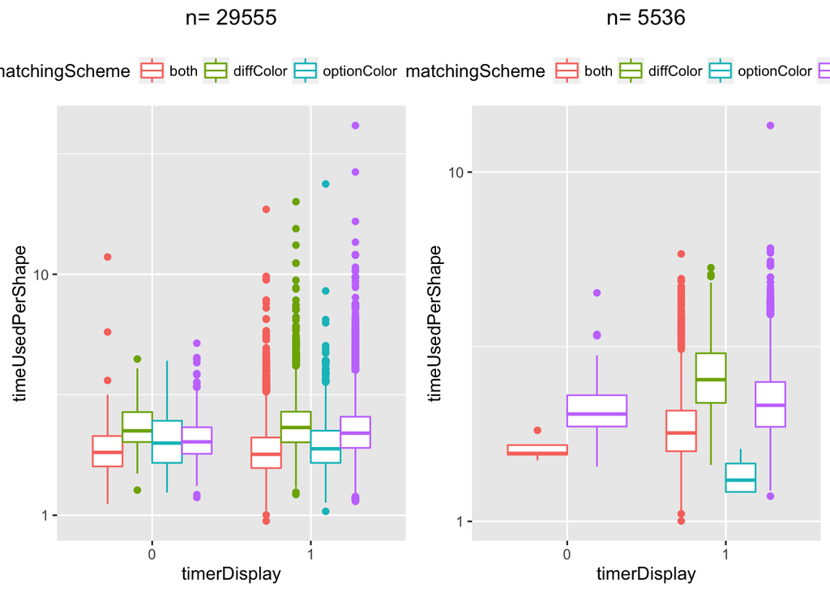

```r
plot5=ggplot(data = shape_untimed_truncate, aes(x=timerDisplay, y=timeUsedPerShape)) + geom_boxplot()  + aes(colour=matchingScheme) + scale_y_log10() + theme(legend.position="top") + labs(title=paste("n=",dim(shape_untimed_truncate)[1]))

plot6=ggplot(data = group_6002, aes(x=timerDisplay, y=timeUsedPerShape)) + geom_boxplot()  + aes(colour=matchingScheme) + scale_y_log10() + theme(legend.position="top") + labs(title=paste("n=",dim(group_6002)[1]))
grid.arrange(plot5,plot6,ncol=2)
```

### Linear Regression:

```r
mod5 <- lm(timeUsedPerShape ~ matchingScheme + timerDisplay, data = shape_untimed_truncate)
mod6 <- lm(timeUsedPerShape ~ matchingScheme + timerDisplay, data = group_6002)

summary(mod5)
```

```
##
## Call:
## lm(formula = timeUsedPerShape ~ matchingScheme + timerDisplay,
##     data = shape_untimed_truncate)
##
## Residuals:
##    Min     1Q Median     3Q    Max
## -1.218 -0.405 -0.133  0.229 39.143
##
## Coefficients:
##                           Estimate Std. Error t value Pr(>|t|)
## (Intercept)                1.81475    0.02631  68.971  < 2e-16 ***
## matchingSchemediffColor    0.49783    0.01390  35.822  < 2e-16 ***
## matchingSchemeoptionColor  0.12684    0.02276   5.573 2.52e-08 ***
## matchingSchemeshape        0.37843    0.01176  32.192  < 2e-16 ***
## timerDisplay1              0.12422    0.02489   4.991 6.03e-07 ***
## ---
## Signif. codes:  0 '***' 0.001 '**' 0.01 '*' 0.05 '.' 0.1 ' ' 1
##
## Residual standard error: 0.7335 on 29550 degrees of freedom
## Multiple R-squared:  0.04986,    Adjusted R-squared:  0.04973
## F-statistic: 387.6 on 4 and 29550 DF,  p-value: < 2.2e-16
```

```r
summary(mod6)
```

```
##
## Call:
## lm(formula = timeUsedPerShape ~ matchingScheme + timerDisplay,
##     data = group_6002)
##
## Residuals:
##     Min      1Q  Median      3Q     Max
## -1.2031 -0.3731 -0.1218  0.2195 11.3351
##
## Coefficients:
##                           Estimate Std. Error t value Pr(>|t|)
## (Intercept)                1.79660    0.05526  32.512   <2e-16 ***
## matchingSchemediffColor    0.72490    0.02997  24.185   <2e-16 ***
## matchingSchemeoptionColor -0.56441    0.29919  -1.886   0.0593 .
## matchingSchemeshape        0.32999    0.01752  18.831   <2e-16 ***
## timerDisplay1              0.13281    0.05366   2.475   0.0134 *
## ---
## Signif. codes:  0 '***' 0.001 '**' 0.01 '*' 0.05 '.' 0.1 ' ' 1
##
## Residual standard error: 0.5978 on 5531 degrees of freedom
## Multiple R-squared:  0.114,  Adjusted R-squared:  0.1134
## F-statistic: 177.9 on 4 and 5531 DF,  p-value: < 2.2e-16
```

### 4 Compare between two subsets

Log(timeUsedPerShape) ~ timerDisplay, colored by matchingScheme **Note: still working on the code to nicely juxatpose two graphs together without squeeshing either. Here the purple plots on the left is ‘shape’.**

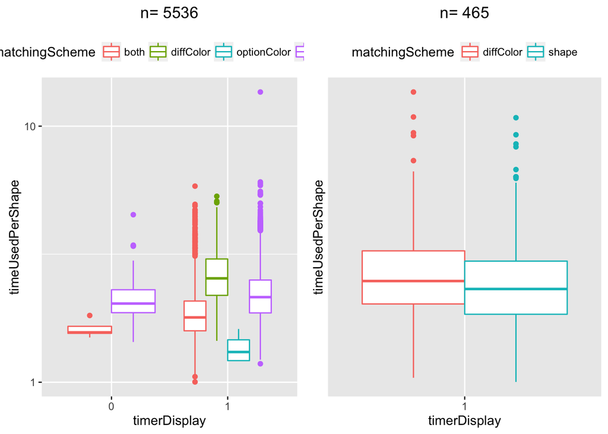

Finding: Now for the smaller sample, we only have a single level for timerDisplay. Derived from previous finding that timerDisplay generally corresponds to longer timeUsedPerShape, the mean of the smaller sample is likely to be an overestimation of the population mean since it does not have any data without timerDisplay. Here is how small sample can easily be misleading to understand the entire picture.

## Approach 2: Plots of Same Dataset With Different Number of Variables

### Using errorPerShape as response

```r
shape_untimed_sec$numShapes=as.numeric(shape_untimed_sec$numShapes)
shape_untimed_sec = mutate(shape_untimed_sec, errorPerShape=shape_untimed_sec$numErrors / shape_untimed_sec$numShapes)
```

### 8.Effects of looking at one additional fixed variable (‘TimerDisplay’)

### Sample untimed

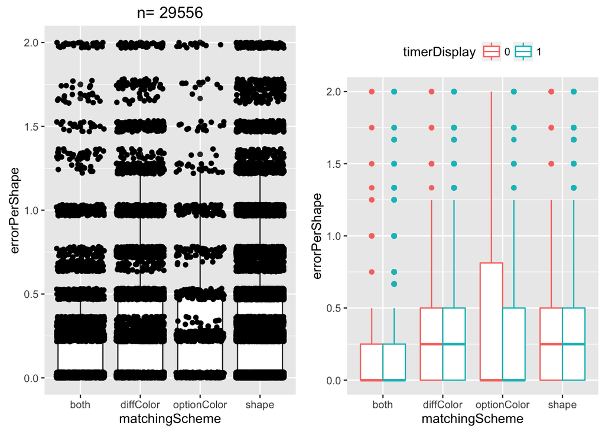

```r
library(gridExtra)
plot7 <- ggplot(data = shape_untimed_sec, aes(x=matchingScheme, y=errorPerShape)) + geom_boxplot() + geom_point(position = "jitter")  + theme(legend.position="top") + labs(title=paste("n=",dim(shape_untimed_sec)[1]))+ylim(0,2)

plot8 <- ggplot(data = shape_untimed_sec, aes(x=matchingScheme, y=errorPerShape)) +  geom_boxplot()  + aes(colour=timerDisplay) + theme(legend.position="top") + labs(title="") +ylim(0,2)

grid.arrange(plot7, plot8, ncol=2)
```

### Linear Regression (untimed Sample)

```r
mod10 <- lm(errorPerShape ~ matchingScheme, data = shape_untimed_sec)
mod20 <- lm(errorPerShape ~ timerDisplay, data = shape_untimed_sec)
mod30 <- lm(errorPerShape ~ matchingScheme + timerDisplay, data = shape_untimed_sec)
summary(mod10)
```

```
##
## Call:
## lm(formula = errorPerShape ~ matchingScheme, data = shape_untimed_sec)
##
## Residuals:
##     Min      1Q  Median      3Q     Max
## -0.5204 -0.4762 -0.2704  0.0604 27.5238
##
## Coefficients:
##                           Estimate Std. Error t value Pr(>|t|)
## (Intercept)                0.27290    0.01262  21.622  < 2e-16 ***
## matchingSchemediffColor    0.24750    0.01700  14.562  < 2e-16 ***
## matchingSchemeoptionColor  0.16102    0.02782   5.788 7.21e-09 ***
## matchingSchemeshape        0.20326    0.01438  14.139  < 2e-16 ***
## ---
## Signif. codes:  0 '***' 0.001 '**' 0.01 '*' 0.05 '.' 0.1 ' ' 1
##
## Residual standard error: 0.8971 on 29552 degrees of freedom
## Multiple R-squared:  0.008388,   Adjusted R-squared:  0.008287
## F-statistic: 83.32 on 3 and 29552 DF,  p-value: < 2.2e-16
```

```r
summary(mod20)
```

```
##
## Call:
## lm(formula = errorPerShape ~ timerDisplay, data = shape_untimed_sec)
##
## Residuals:
##     Min      1Q  Median      3Q     Max
## -0.4493 -0.4493 -0.1993  0.0507 27.5507
##
## Coefficients:
##               Estimate Std. Error t value Pr(>|t|)
## (Intercept)    0.43460    0.03008  14.449   <2e-16 ***
## timerDisplay1  0.01469    0.03054   0.481    0.631
## ---
## Signif. codes:  0 '***' 0.001 '**' 0.01 '*' 0.05 '.' 0.1 ' ' 1
##
## Residual standard error: 0.9008 on 29554 degrees of freedom
## Multiple R-squared:  7.825e-06,  Adjusted R-squared:  -2.601e-05
## F-statistic: 0.2313 on 1 and 29554 DF,  p-value: 0.6306
```

```r
summary(mod30)
```

```
##
## Call:
## lm(formula = errorPerShape ~ matchingScheme + timerDisplay, data = shape_untimed_sec)
##
## Residuals:
##     Min      1Q  Median      3Q     Max
## -0.5207 -0.4766 -0.2591  0.0600 27.5234
##
## Coefficients:
##                           Estimate Std. Error t value Pr(>|t|)
## (Intercept)                0.25911    0.03218   8.052 8.45e-16 ***
## matchingSchemediffColor    0.24743    0.01700  14.558  < 2e-16 ***
## matchingSchemeoptionColor  0.16140    0.02783   5.799 6.75e-09 ***
## matchingSchemeshape        0.20333    0.01438  14.143  < 2e-16 ***
## timerDisplay1              0.01417    0.03044   0.466    0.642
## ---
## Signif. codes:  0 '***' 0.001 '**' 0.01 '*' 0.05 '.' 0.1 ' ' 1
##
## Residual standard error: 0.8971 on 29551 degrees of freedom
## Multiple R-squared:  0.008395,   Adjusted R-squared:  0.008261
## F-statistic: 62.54 on 4 and 29551 DF,  p-value: < 2.2e-16
```

### Using ‘6002’ Sample:

[figure not shown]

```r
plot11 <- ggplot(data = group_6002, aes(x=matchingScheme, y=errorPerShape)) + geom_boxplot()  + theme(legend.position="top") + labs(title=paste("n=",dim(shape_untimed_sec)[1]))+ylim(0,1.5)

plot12 <- ggplot(data = group_6002, aes(x=matchingScheme, y=errorPerShape)) +  geom_boxplot()  + aes(colour=timerDisplay) + theme(legend.position="top") + labs(title="") +ylim(0,1.5)

grid.arrange(plot11, plot12, ncol=2)
```

### Linear Regression (6002)

```r
mod11 <- lm(errorPerShape ~ matchingScheme, data = group_6002)
mod21 <- lm(errorPerShape ~ timerDisplay, data = group_6002)
mod31 <- lm(errorPerShape ~ matchingScheme + timerDisplay, data = group_6002)
summary(mod11)
```

```
##
## Call:
## lm(formula = errorPerShape ~ matchingScheme, data = group_6002)
##
## Residuals:
##      Min       1Q   Median       3Q      Max
## -0.09268 -0.05141 -0.03494  0.01268  1.07359
##
## Coefficients:
##                           Estimate Std. Error t value Pr(>|t|)
## (Intercept)               0.034939   0.002071  16.868  < 2e-16 ***
## matchingSchemediffColor   0.057745   0.004510  12.803  < 2e-16 ***
## matchingSchemeoptionColor 0.025478   0.045023   0.566    0.571
## matchingSchemeshape       0.016467   0.002620   6.285 3.54e-10 ***
## ---
## Signif. codes:  0 '***' 0.001 '**' 0.01 '*' 0.05 '.' 0.1 ' ' 1
##
## Residual standard error: 0.08995 on 5532 degrees of freedom
## Multiple R-squared:  0.02931,    Adjusted R-squared:  0.02879
## F-statistic: 55.68 on 3 and 5532 DF,  p-value: < 2.2e-16
```

```r
summary(mod21)
```

```
##
## Call:
## lm(formula = errorPerShape ~ timerDisplay, data = group_6002)
##
## Residuals:
##      Min       1Q   Median       3Q      Max
## -0.05072 -0.04953 -0.04953  0.00602  1.07547
##
## Coefficients:
##                Estimate Std. Error t value Pr(>|t|)
## (Intercept)    0.050720   0.008037   6.311 2.99e-10 ***
## timerDisplay1 -0.001188   0.008132  -0.146    0.884
## ---
## Signif. codes:  0 '***' 0.001 '**' 0.01 '*' 0.05 '.' 0.1 ' ' 1
##
## Residual standard error: 0.09128 on 5534 degrees of freedom
## Multiple R-squared:  3.853e-06,  Adjusted R-squared:  -0.0001768
## F-statistic: 0.02132 on 1 and 5534 DF,  p-value: 0.8839
```

```r
summary(mod31)
```

```
##
## Call:
## lm(formula = errorPerShape ~ matchingScheme + timerDisplay, data = group_6002)
##
## Residuals:
##      Min       1Q   Median       3Q      Max
## -0.09268 -0.05141 -0.03494  0.01268  1.07359
##
## Coefficients:
##                            Estimate Std. Error t value Pr(>|t|)
## (Intercept)               0.0348895  0.0083162   4.195 2.77e-05 ***
## matchingSchemediffColor   0.0577453  0.0045109  12.801  < 2e-16 ***
## matchingSchemeoptionColor 0.0254780  0.0450269   0.566    0.572
## matchingSchemeshape       0.0164686  0.0026372   6.245 4.56e-10 ***
## timerDisplay1             0.0000491  0.0080755   0.006    0.995
## ---
## Signif. codes:  0 '***' 0.001 '**' 0.01 '*' 0.05 '.' 0.1 ' ' 1
##
## Residual standard error: 0.08996 on 5531 degrees of freedom
## Multiple R-squared:  0.02931,    Adjusted R-squared:  0.02861
## F-statistic: 41.76 on 4 and 5531 DF,  p-value: < 2.2e-16
```

## overlaying jitterplots with boxplots: (not looking great)

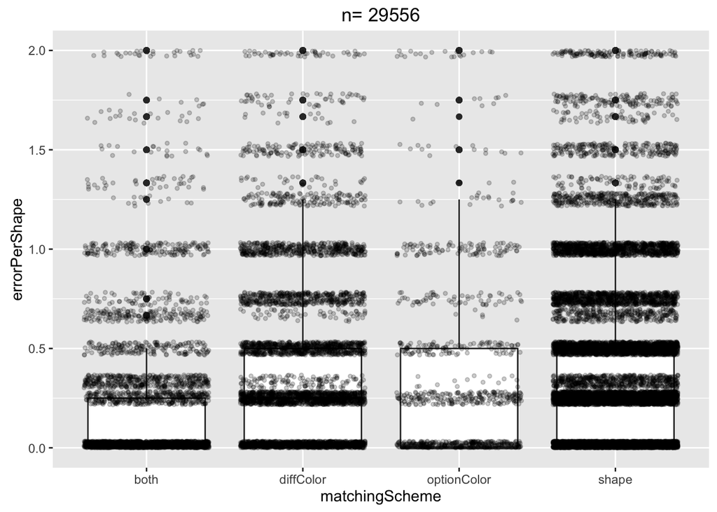

```r
ggplot(data = shape_untimed_sec, aes(x=matchingScheme, y=errorPerShape)) + geom_boxplot() + geom_jitter(size= 1, alpha=0.2) + theme(legend.position="top") + labs(title=paste("n=",dim(shape_untimed_sec)[1]))+ylim(0,2)
```

```r
##geom_point(position = "jitter")  +
```